# What the head can hold

Week 6 · Chapter 7 · Human Memory and Cognition

Study · Week 6

Read Chapter 7 of the textbook (Eggen & Kauchak, 2025) before you read this brief. The chapter presents the whole memory system, and the brief concentrates on the two ideas you will use for design in the rest of the unit: **how little the brain can hold at once**, and **what makes things stay**.

About 25 minutes: reading, one place you stop and write, and 8 quick checks.

Pair this with **the case study video walkthrough**.

## Common belief

Some people believe that forgetting is a failure of effort or that people just have bad memory. If students forget, we conclude that they did not try hard enough, or they blame their own memory. Chapter 7 offers a different explanation.

Try a short test. Read the next line once, look away, and say it back:

> *notebook · clean page · date · title · pencil · not yellow · copy · think about last week*

Most people remember the first three and the last one. The same thing happened to Matthew.

## Information Processing System

[figure not shown]

The bottleneck is the middle box. Everything a teacher says, every line a tool produces, has to pass through a storing system (Working Memory) that holds about four things for about twenty seconds (Cowan, 2001).

Sensory register: everything, briefly. It has a large capacity and lasts less than a second. Whatever we do not attend to is lost, and attention can admit very little at a time.

Working memory: the workspace. Miller (1956) estimated 7 ± 2 chunks. Cowan’s (2001) better estimate is **about 4**, for about twenty seconds, unless you keep rehearsing. Thinking happens in this small space.

Long-term memory: the storage. It has no known capacity limit, and it includes declarative knowledge (facts, episodes) and procedural knowledge (skills). The difficulty is getting things in (encoding) and getting them back out (retrieval).

Chunk: one thing, as far as working memory is concerned. *F-B-I-C-I-A* is six letters or two chunks, depending on what you already know. **Prior knowledge is what makes chunks.** For this reason, experts who have accumulated a lot of knowledge seem to handle more information, because their chunks are bigger.

*Defeating pop-culture:* Working memory is not a small version of long-term memory. It is a **different kind of thing**, like a workspace with room for about four items, and every one of your instructions, examples and slides competes for those four slots.

True or false?

Experts handle more information because their working memory has more slots.

Not quite Experts have the same four or so slots. Their **chunks** are bigger, because prior knowledge packs many items into one.

Right The number of slots is the same, and the chunks are bigger because of prior knowledge.

## Cognitive load

Sweller (1988) asked what occupies those four slots at any moment. Three types of load compete for the same space, and knowing which one we are adding helps us design for learning.

Intrinsic load: how hard the material is, in itself. It depends on how many elements a learner has to hold *at once* to understand the material. Osmosis is high, and the capital of Brazil is low. You cannot remove intrinsic load, but you can **sequence and chunk** it.

Extraneous load: everything that occupies the workspace and is not the material. Examples are decorative slides, instructions delivered in a block of four, copying a diagram in three colors, and a tool that answers a question with eight hundred words. **A teacher or a prompt can remove this load.**

Germane load: the effort that builds the schema. Examples are explaining an idea back, predicting before you check, and comparing two cases. This is the cognitive load you *want*, and it is available only when the other two have left room for it. (Note: current reviews of cognitive load theory keep only two types, intrinsic and extraneous.)

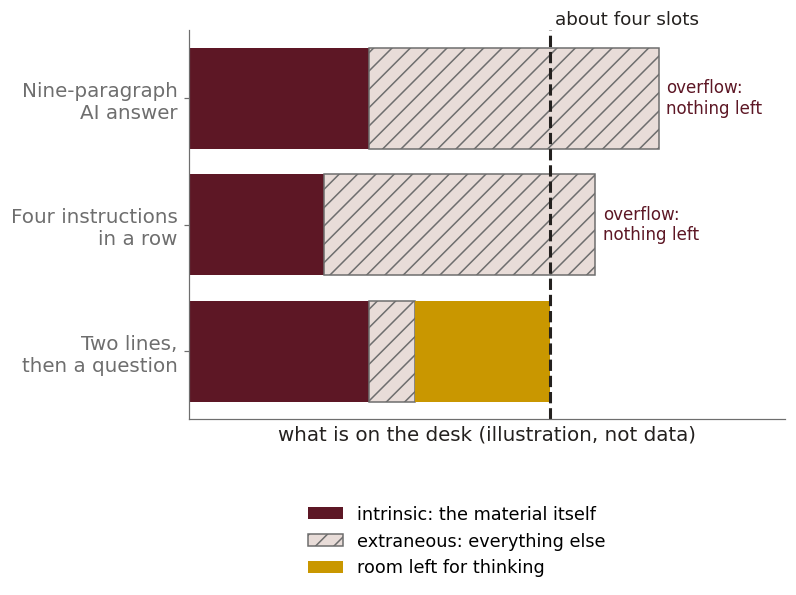

Three designs on the same four-slot desk. Extraneous load decides whether any room is left for thinking.

True or false?

A teacher can lower the intrinsic load of a topic by making the slides simpler.

Not quite Simpler slides lower **extraneous** load. Intrinsic load belongs to the material. You can only sequence and chunk it.

Right Slides add extraneous load. Intrinsic load can be sequenced and chunked, but it cannot be removed.

**Busy is not the same as learning.** Priya copied the diagram exactly, in three colors, with every label. All of that work was extraneous load, because it filled her working memory with the task of copying and left nothing for thinking about the question the diagram was for. She looked like the most engaged student in the room, and she encoded the least.

Practice

A student asks an AI tool to explain a concept from your subject. It returns a correct, well-organized, **nine-paragraph** answer. The student reads it all and says it made sense.

**Which kind of load did the nine paragraphs mostly add, and what would you predict the student can say about the concept tomorrow?** Explain how the load leads to your prediction. Two or three sentences.

**The paragraphs mostly added extraneous load. Tomorrow the student will remember that the answer made sense, and will not remember what it said or how to use it.**

Nine paragraphs contain more than working memory can hold in any order. A reader of such a text *recognizes* each sentence as sensible as it passes, which feels exactly like understanding. The reader has not chunked, generated or retrieved anything, because the tool did the work while the student watched.

Milestone 2 asks you to solve this design problem. A tool that teaches has to be told **how much to say per turn, and what to make the learner do with it**. That number, the output limit, is a cognitive load decision for you to make.

## Encoding

Long-term memory does not store information only because you were exposed to it, which is why lectures alone are ineffective. It stores what you **do** with the information. The chapter describes these factors:

Attention: the precondition. Nothing unattended is encoded. Divided attention does more than reduce encoding by half, because it often removes it. Doing homework with Netflix on is an encoding problem.

Elaboration: connecting new information to something already known. *Why* does salt water pull water out of celery? A learner who can answer has attached the new fact to a structure, whereas a learner who only remembers lists of facts will forget them.

Organization: imposing a structure. Outlines, concept maps and tables turn a lot of loose information into manageable chunks. They work when the *learner* builds them, because a finished structure is one more thing to hold.

Dual coding: words and an image, together. They provide two routes in and two routes back. No one is a visual learner, but graphs matched with words help encoding.

Generation: producing an answer. Writing the definition is better than reading it, and solving the problem is better than studying the solution, once you know enough to solve it. The retrieval check exists because of the generation effect.

These factors have different costs. Attention is free and mandatory, whereas elaboration and generation are expensive and produce the learning. **The learner has to do every one of them, and a summary cannot do any of them for the learner.**

Check yourself

Which study move does the most encoding work?

Attention without generation Highlighting selects sentences. It does not connect them to anything you already know.

Recognition only Rereading feels like knowing because every line is familiar.

Yes That is elaboration and generation together: you build the connection yourself.

Exposure only Long-term memory stores what you do with information.

**The offloading trap.** Donghwee (this name is based on my Korean friend at Purdue in 2015) asked a tool to summarize, then to pick the three main points, then to make him a mnemonic. Each step was a good study strategy, but it was *done by the tool.* Donghwee did not perform the elaboration in the summary, and he did not build the organization in the mnemonic. He arrived able to recite the product of comprehension without having done the thinking himself, and the first question outside the mnemonic found the gap.

The argument is about **who does the encoding**, and it does not mean that you should avoid the tool. Nobody memorizes what they trust the search bar or the chatbot to hold for them (Sparrow et al., 2011, showed this for Google). That is fine for the capital of Brazil and fatal for what you need under time pressure in a room where the tool is not available. Deciding which is which is Part 2 of Milestone 2.

True or false?

A mnemonic a chatbot makes for you works as well as one you make yourself, because the mnemonic is the same.

Not quite Building the mnemonic is the organization that makes it stick. Receiving a finished one skips that work.

Right The value is in building it. A finished mnemonic is one more thing to hold.

## Retrieval

Storage is rarely the problem. The chapter’s causes of forgetting (decay, interference and retrieval failure) mostly describe ways in which stored information becomes unreachable.

Recall vs recognition Recognition (*was it this one?*) is easy and misleading, because rereading feels like knowing when every line is familiar. Recall (*what was it?*) is the real test and the real practice.

Retrieval cues We reach memories by association. Information with more routes in has more routes back, which is why elaboration works for encoding.

Interference In proactive interference, the old password blocks the new one. In retroactive interference, learning this chapter makes last unit’s harder to reach. Similar material, learned close together, is the worst case.

Encoding failure The information was never stored, so it was not forgotten. Most “I forgot” in a classroom is an encoding failure. Matthew did not forget instructions three and four, because he did not pay attention to them.

Check yourself

After changing her school email password, Ms. Rivera keeps typing the old one. This is:

Other direction Retroactive means new learning blocks the old. Here the old password blocks the new one.

Yes Old learning gets in the way of new learning. Similar material learned close together is the worst case.

She stored it She knows the new password, but the old one is retrieved first.

Nothing faded The old password is stronger, and that is the problem.

### Strategies that work, and why

The table shows the chapter’s strategies with the mechanism of each one. A strategy you can explain is a strategy you can adapt, and one you can tell a tool to use.

| Strategy | What it does | Weak imitation |
| --- | --- | --- |
| **Retrieval practice** | strengthens the route back; each successful recall makes the next easier | rereading — recognition dressed as recall |
| **Spacing** | forces re-retrieval after partial forgetting, which is when retrieval builds most | cramming — one long rehearsal, gone in a week |
| **Interleaving** | mixes problem types so the learner has to choose the method, not just execute it | blocked practice — twenty identical problems |
| **Self-explanation** | elaboration in the learner’s own words; exposes the gap | highlighting the book — attention without generation |
| **Chunking** | converts many items into few by attaching them to a structure | a mnemonic for a list the learner does not understand |
| **Dual coding** | two representations, two retrieval routes | decorative images — extraneous load with a picture |

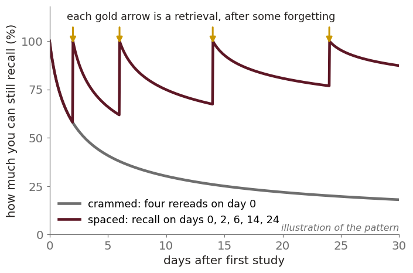

Cramming versus spaced recall. Each retrieval after some forgetting slows the next round of forgetting (Cepeda et al., 2006).

**Every strategy in the left column is *harder* at the time than its imitation on the right.** Bjork and Bjork (2011) call this a *desirable difficulty*. It explains why learners who can choose reliably pick the easier tasks, which feel better and work worse. It also explains why an AI tool, programmed to be helpful right now, defaults to the right-hand column unless it is told not to.

True or false?

If a study strategy feels easy and fluent, it is probably working.

Not quite Fluency is misleading. The strategies that work feel *harder* at the time, which Bjork and Bjork call desirable difficulty.

Right The strategies in the left column feel harder and work better. Easy and fluent usually means recognition.

## Working memory and the context window of AI

Large language models have a working memory too (Kinda). It is called the **context window**, and it holds what you have said and what the model has said. When it fills (about 250k-1M tokens according to the Model), some of the information must be dropped, so a long conversation with a tool drifts. Your AI task this week (**Compare**) shows a similar problem on your side. A messy, unchunked prompt degrades the answer for the same structural reason that a block of four instructions degraded Matthew’s work. The tool’s output is *your* extraneous load, and a poorly structured prompt is the chatbot’s extraneous load.

## Check yourself

Check yourself

A teacher gives four verbal instructions in a row, including one thinking task. Most of the class completes the first two. The most precise account is:

The explanation that requires nothing of the teacher They may have been attending perfectly. Four items plus a thinking task are more than a four-slot store can hold. Attention is necessary, but it is not sufficient.

Yes This is an encoding failure. Items three and four were never stored, so no amount of effort can retrieve them. The teacher can change the delivery: chunk the instructions, write them, or sequence them.

Decay needs something to decay Decay describes stored information that fades. Retaining the first items (primacy) and losing the later ones is the signature of a capacity limit at encoding.

Wrong mechanism Interference is competition between similar stored material. Nothing here suggests that the old routine is being produced in place of the new one, because the later instructions are simply absent.

Check yourself

A student prepares for a test by rereading their notes four times. They feel confident and score poorly. The best explanation is:

Spacing would help, but not for that reason Spacing works by forcing *retrieval* after partial forgetting. Four spaced rereadings are still four recognitions, so the missing ingredient is recall.

Nothing suggests it Rereading correct notes produces exactly this pattern. Priya’s notes in next week’s case are flawless.

Yes The student recognizes every reread line as familiar and misreads familiarity as knowledge, which is the calibration error the chapter warns about. The test asked for recall, which the student had never practiced. Retrieval practice, self-explanation or generation would have exposed the gap before the test did.

Not established The student was confident and had time. The problem is in *how* they studied, and nothing points to the material’s element interactivity.

Food for thought **Can you remember** what Matthew was asked to hold, and the number you compared it to?

**One thing you have offloaded to a device this month** that you would once have carried in your brain, and whether it matters.

**The last thing you asked an AI, and what it answered.** If you cannot remember the answer, treat that as data.

**Retrieval check** Can you ace the reading quiz without help? Can you apply the concepts now?

*This week feeds Milestone 2, how the tool helps/hinders cognitive load and information processing*

## Sources

Bjork, R. A., & Bjork, E. L. (2011). Making things hard on yourself, but in a good way: Creating desirable difficulties to enhance learning. In M. A. Gernsbacher, R. W. Pew, L. M. Hough, & J. R. Pomerantz (Eds.), *Psychology and the real world* (pp. 56–64). Worth Publishers.

Cepeda, N. J., Pashler, H., Vul, E., Wixted, J. T., & Rohrer, D. (2006). Distributed practice in verbal recall tasks: A review and quantitative synthesis. *Psychological Bulletin, 132*(3), 354–380.

Cowan, N. (2001). The magical number 4 in short-term memory: A reconsideration of mental storage capacity. *Behavioral and Brain Sciences, 24*(1), 87–114.

Eggen, P. D., & Kauchak, D. P. (2025). *Using educational psychology in teaching* (12th ed.). Pearson. **This week: Chapter 7.**

Leppink, J., Paas, F., Van der Vleuten, C. P. M., Van Gog, T., & Van Merriënboer, J. J. G. (2013). Development of an instrument for measuring different types of cognitive load. *Behavior Research Methods, 45*(4), 1058–1072.

Miller, G. A. (1956). The magical number seven, plus or minus two: Some limits on our capacity for processing information. *Psychological Review, 63*(2), 81–97.

Sparrow, B., Liu, J., & Wegner, D. M. (2011). Google effects on memory: Cognitive consequences of having information at our fingertips. *Science, 333*(6043), 776–778.

Sweller, J. (1988). Cognitive load during problem solving: Effects on learning. *Cognitive Science, 12*(2), 257–285.